# Working with 3D city models in Python

**Balázs Dukai** [*@BalazsDukai*](https://twitter.com/balazsdukai), **FOSS4G 2019**

Tweet #CityJSON

[3D geoinformation research group, TU Delft, Netherlands](https://3d.bk.tudelft.nl/)

[figure not shown]

Repo of this talk: https://github.com/balazsdukai/foss4g2019

# 3D + city + model ?

[figure not shown]

# Semantic models

[figure not shown]

# Useful for urban analysis

[figure not shown]

García-Sánchez, C., van Beeck, J., Gorlé, C., Predictive Large Eddy Simulations for Urban Flows: Challenges and Opportunities, Building and Environment, 139, 146-156, 2018.

# And many more...

[figure not shown]

# ...mostly just production of the models

many available, but who **uses** them? **For more than visualisation?**

[figure not shown]

# In truth, 3D CMs are a bit difficult to work with

### Our built environment is complex, and the objects are complex too

[figure not shown]

### Software are lagging behind

- not many software supports 3D city models
- if they do, mostly propietary data model and format
- large, *"eterprise"*-type applications (think Esri, FME, Bentley ... )
- few tools accessible for the individual developer / hobbyist

[figure not shown]

## Key concepts of CityJSON

- *simple*, as in easy to implement
- designed with programmers in mind
- fully developed in the open
- flattened hierarchy of objects
- implementation first

[figure not shown]

# JSON-based encoding of the CityGML data model

[figure not shown]

## Compression ~6x over CityGML

[figure not shown]

https://xkcd.com/927/

# Let's have a look-see, shall we?

[figure not shown]

## An empty CityJSON file

[figure not shown]

## A CityObject

[figure not shown]

## Geometry

- **boundaries** definition uses vertex indices (inspired by Wavefront OBJ)
- We have a vertex list at the root of the document
- Vertices are not repeated (unlike Simple Features)
- **semantics** are linked to the boundary surfaces

[figure not shown]

```python
import json
import os

path = os.path.join('data', 'rotterdam_subset.json')
with open(path) as fin:
    cm = json.loads(fin.read())

print(f"There are {len(cm['CityObjects'])} CityObjects")

# list all IDs
for id in cm['CityObjects']:
    print(id, "\t")
```

```
There are 16 CityObjects
{C9D4A5CF-094A-47DA-97E4-4A3BFD75D3AE}
{71B60053-BC28-404D-BAB9-8A642AAC0CF4}
{6271F75F-E8D8-4EE4-AC46-9DB02771A031}
{DE77E78F-B110-43D2-A55C-8B61911192DE}
{19935DFC-F7B3-4D6E-92DD-C48EE1D1519A}
{953BC999-2F92-4B38-95CF-218F7E05AFA9}
{8D716FDE-18DD-4FB5-AB06-9D207377240E}
{C6AAF95B-8C09-4130-AB4D-6777A2A18A2E}
{72390BDE-903C-4C8C-8A3F-2DF5647CD9B4}
{8244B286-63E2-436E-9D4E-169B8ACFE9D0}
{87316D28-7574-4763-B9CE-BF6A2DF8092C}
{CD98680D-A8DD-4106-A18E-15EE2A908D75}
{64A9018E-4F56-47CD-941F-43F6F0C4285B}
{459F183A-D0C2-4F8A-8B5F-C498EFDE366D}
{237D41CC-991E-4308-8986-42ABFB4F7431}
{23D8CA22-0C82-4453-A11E-B3F2B3116DB4}
```

- Working with a CityJSON file is straightforward. One can open it with the standard library and get going.
- But you need to know the schema well.
- And you need to write everything from scratch.

[figure not shown]

## `cjio` has a (quite) stable CLI

```
$ cjio city_model.json reproject 2056 export --format glb /out/model.glb
```

## and an experimental API

```
from cjio import cityjson

cm = cityjson.load('city_model.json')

cm.get_cityobjects(type='building')
```

**`pip install cjio`**

**`pip install git+https://github.com/tudelft3d/cjio@develop`**

# `cjio`'s CLI

```python
! cjio --help
```

```
Usage: cjio [OPTIONS] INPUT COMMAND1 [ARGS]... [COMMAND2 [ARGS]...]...

  Process and manipulate a CityJSON file, and allow different outputs. The
  different operators can be chained to perform several processing in one
  step, the CityJSON model goes through the different operators.

  To get help on specific command, eg for 'validate':

      cjio validate --help

  Usage examples:

      cjio example.json info validate
      cjio example.json assign_epsg 7145 remove_textures export output.obj
      cjio example.json subset --id house12 save out.json

Options:
  --version                Show the version and exit.
  --ignore_duplicate_keys  Load a CityJSON file even if some City Objects have
                           the same IDs (technically invalid file)
  --help                   Show this message and exit.

Commands:
  assign_epsg                Assign a (new) EPSG.
  clean                      Clean = remove_duplicate_vertices +...
  compress                   Compress a CityJSON file, ie stores its...
  decompress                 Decompress a CityJSON file, ie remove the...
  export                     Export the CityJSON to another format.
  extract_lod                Extract only one LoD for a dataset.
  info                       Output info in simple JSON.
  locate_textures            Output the location of the texture files.
  merge                      Merge the current CityJSON with others.
  partition                  Partition the city model into tiles.
  remove_duplicate_vertices  Remove duplicate vertices a CityJSON file.
  remove_materials           Remove all materials from a CityJSON file.
  remove_orphan_vertices     Remove orphan vertices a CityJSON file.
  remove_textures            Remove all textures from a CityJSON file.
  reproject                  Reproject the CityJSON to a new EPSG.
  save                       Save the city model to a CityJSON file.
  subset                     Create a subset of a CityJSON file.
  translate                  Translate the file by its (-minx, -miny,...
  update_bbox                Update the bbox of a CityJSON file.
  update_textures            Update the location of the texture files.
  upgrade_version            Upgrade the CityJSON to the latest version.
  validate                   Validate the CityJSON file: (1) against its...
```

```python
! cjio data/rotterdam_subset.json info
```

```
Parsing data/rotterdam_subset.json
{
  "cityjson_version": "1.0",
  "epsg": 7415,
  "bbox": [
    90454.18900000001,
    435614.88,
    0.0,
    91002.41900000001,
    436048.217,
    18.29
  ],
  "transform/compressed": true,
  "cityobjects_total": 16,
  "cityobjects_present": [
    "Building"
  ],
  "materials": false,
  "textures": true
}
```

```python
! cjio data/rotterdam_subset.json \
    subset --exclude --id "{CD98680D-A8DD-4106-A18E-15EE2A908D75}" \
    merge data/rotterdam_one.json \
    reproject 2056 \
    save data/test_rotterdam.json
```

```
Parsing data/rotterdam_subset.json
Subset of CityJSON
Merging files
Reproject to EPSG:2056
  [####################################]  100%
Saving CityJSON to a file /home/balazs/Reports/talk_cjio_foss4g_2019/data/test_rotterdam.json
```

- The CLI was first, no plans for API
- **Works with whole city model only**
- Functions for the CLI work with the JSON directly, passing it along
- Simple and effective architecture

# `cjio`'s API

Allow *read* --> *explore* --> *modify* --> *write* iteration

Work with CityObjects and their parts

Functions for common operations

Inspired by the *tidyverse* from the R ecosystem

## Load a CityJSON

```python
path = os.path.join('data', 'rotterdam_subset.json')

cm = cityjson.load(path)

print(type(cm))
```

```
<class 'cjio.cityjson.CityJSON'>
```

## Getting objects from the model

Get CityObjects by their *type*, or a list of types. Also by their IDs.

Note that `get_cityobjects()` == `cm.cityobjects`

```python
buildings = cm.get_cityobjects(type='building')

# both Building and BuildingPart objects
buildings_parts = cm.get_cityobjects(type=['building', 'buildingpart'])

r_ids = ['{C9D4A5CF-094A-47DA-97E4-4A3BFD75D3AE}',
         '{6271F75F-E8D8-4EE4-AC46-9DB02771A031}']
buildings_ids = cm.get_cityobjects(id=r_ids)
```

# Analysing CityModels

[figure not shown]

```python
path = os.path.join('data', 'zurich.json')
zurich = cityjson.load(path, transform=True)
```

## A simple geometry function

```python
def compute_footprint_area(co):
    """Compute the area of the footprint"""
    footprint_area = 0
    for geom in co.geometry:

        # only LoD2 (or higher) objects have semantic surfaces
        if geom.lod >= 2.0:
            footprints = geom.get_surfaces(type='groundsurface')

            # there can be many surfaces with label 'groundsurface'
            for i,f in footprints.items():
                for multisurface in geom.get_surface_boundaries(f):
                    for surface in multisurface:

                        # cast to Shapely polygon
                        shapely_poly = Polygon(surface)
                        footprint_area += shapely_poly.area

    return footprint_area
```

## Compute new attributes

```python
for co_id, co in zurich.cityobjects.items():
    co.attributes['nr_vertices'] = len(co.get_vertices())
    co.attributes['fp_area'] = compute_footprint_area(co)
    zurich.cityobjects[co_id] = co
```

```python
df = zurich.to_dataframe()
df.head()
```

|  | creationDate | Geomtype | nr_vertices | fp_area | class | Herkunft | QualitaetStatus | FileCreationDate | Region | GebaeudeStatus |
| --- | --- | --- | --- | --- | --- | --- | --- | --- | --- | --- |
| UUID_93fc5bae-4446-4336-9ff8-6679ebfdfde3 | 2017-01-23 | 1.0 | 24 | 65.209763 | NaN | NaN | NaN | NaN | NaN | NaN |
| UUID_c9884c4e-1cac-47f5-b88b-6fb074c0ae50 | 2017-01-23 | NaN | 0 | 0.000000 | BB01 | EE_LB_2007 | 1.0 | 2012-02-23 | 2.0 | 1.0 |
| UUID_a4a09780-153f-4385-ad19-3a92a6c4eec4 | 2017-01-23 | 1.0 | 38 | 20.784309 | NaN | NaN | NaN | NaN | NaN | NaN |
| UUID_ba0bb815-5276-4e35-b4c1-878cbf6ba934 | 2017-01-23 | NaN | 0 | 0.000000 | BB07 | EE_LB_2007 | 1.0 | 2012-02-23 | 2.0 | 1.0 |
| UUID_bb1835bc-7437-453f-ac08-885de0503aaa | 2017-01-23 | 1.0 | 87 | 69.363823 | NaN | NaN | NaN | NaN | NaN | NaN |

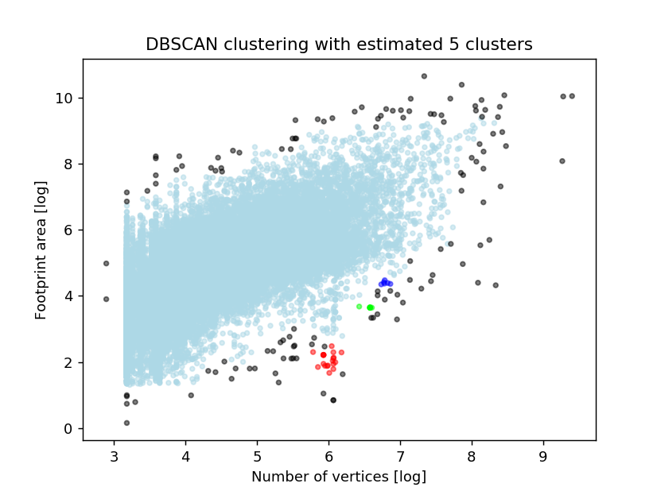

```python
%matplotlib notebook
model = cluster.DBSCAN(eps=0.2).fit(df_logtransform)

plot_model_results(model, df_logtransform)
```

## Save the results back to CityJSON

```python
for co_id, co in zurich.cityobjects.items():
    if co_id in df_subset.index:
        ml_results = dict(df_subset.loc[co_id])
    else:
        ml_results = {'nr_vertices': 'nan', 'fp_area': 'nan', 'dbscan': 'nan'}
    new_attrs = {**co.attributes, **ml_results}
    co.attributes = new_attrs
    zurich.cityobjects[co_id] = co
```

```python
path_out = os.path.join('data', 'zurich_output.json')
cityjson.save(zurich, path_out)
```

## And view the results in QGIS again

[figure not shown]

# Other software

## Online CityJSON viewer

[figure not shown]

## QGIS plugin

[figure not shown]

## Azul

[figure not shown]

# Full conversion CityGML <--> CityJSON

[figure not shown]

# Thank you!

Balázs Dukai

b.dukai@tudelft.nl

@BalazsDukai

## A few links

Repo of this talk: https://github.com/balazsdukai/foss4g2019

cityjson.org

viewer.cityjson.org

QGIS plugin: github.com/tudelft3d/cityjson-qgis-plugin

Azul – CityJSON viewer on Mac – check the [AppStore](https://apps.apple.com/nl/app/azul/id1173239678?mt=12)

cjio: github.com/tudelft3d/cjio & tudelft3d.github.io/cjio/